## Exploring data

## Data from a package

So far we've covered three ways to get data into R:

1. From flat files (either on your computer or online)
2. From files like SAS and Excel
3. From R objects (i.e., using `load()`)

Many R packages come with their own data, which is very easy to load and use.

For example, the `faraway` package, which complements Julian Faraway's book *Linear Models with R*, has a dataset called `worldcup`. To load this dataset, run:

```r
library(faraway)
data("worldcup")
```

Unlike most data objects you'll work with, datasets that are part of an R package will often have their own help files. You can access this help file using the `?` operator:

```r
?worldcup
```

To get a list of all of the datasets that are available in the packages you currently have loaded, run `data()` without an option inside the parentheses:

```r
data()
```

To find out all of the datasets available within a certain package, run e.g.:

```r
data(package = "faraway")
```

## Plots to explore data

Exploratory data analysis is a key step in data analysis, and plotting your data in different ways is an important part of this process.

This section will focus on making **useful**, rather than **attractive** graphs, since at this stage we are focusing on exploring data for yourself rather than presenting results to others.

Here, we'll use the `ggplot2` package (another member of the tidyverse!).

```r
library(ggplot2)
```

The basic steps behind creating a plot with `ggplot2` are:

1. Create an object of the `ggplot` class, typically specifying the **data** and some or all of the **aesthetics**;
2. Add on **geoms** and other elements to create and customize the plot, using `+`.

### Initializing a ggplot object

The first step in creating a plot using `ggplot2` is to create a ggplot object. It typically specifies the data frame you want to use and which aesthetics will be mapped to certain columns of that data frame.

```r
## Generic code
object <- ggplot(data = dataframe,
                 mapping = aes(x = column_1, y = column_2))
```

### Plot aesthetics

**Aesthetics** are properties of the plot that can show certain elements of the data. For example, below, color shows (is mapped to) gender, x-position shows height, and y-position shows weight in a sample data set of measurements of children in Nepal.

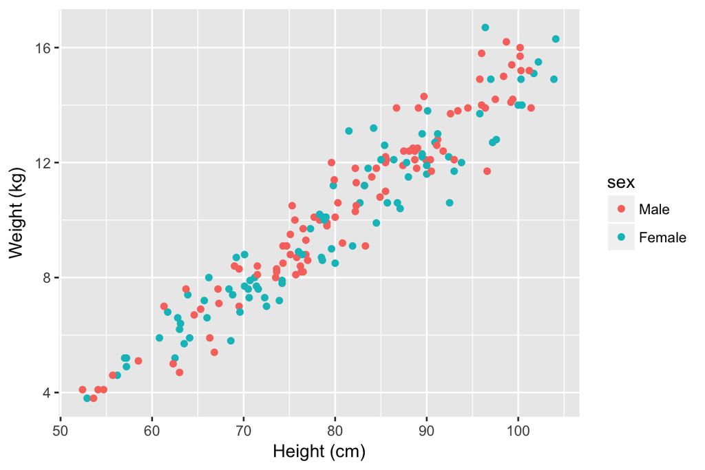

Which aesthetics are required for a plot depend on which geoms you're adding to the plot. You can find out the aesthetics you can use for a geom in the "Aesthetics" section of the geom's help file. Common aesthetics include:

| Code | Description |
| --- | --- |
| `x` | Position on x-axis |
| `y` | Position on y-axis |
| `shape` | Shape |
| `color` | Color of border of elements |
| `fill` | Color of inside of elements |
| `size` | Size |
| `alpha` | Transparency (1: opaque; 0: transparent) |
| `linetype` | Type of line (e.g., solid, dashed) |

### Adding geoms

You will add one or more `geoms` to create the plot.  
Some of the most common geoms are:

| Plot type | ggplot2 function |
| --- | --- |
| Histogram (1 numeric variable) | `geom_histogram` |
| Scatterplot (2 numeric variables) | `geom_point` |
| Boxplot (1 numeric variable, possibly 1 factor variable) | `geom_boxplot` |
| Line graph (2 numeric variables) | `geom_line` |

### Constant aesthetics

Instead of mapping an aesthetic to an element of your data, you can use a constant value for it. For example, you may want to make all the points green, rather than having color map to gender:

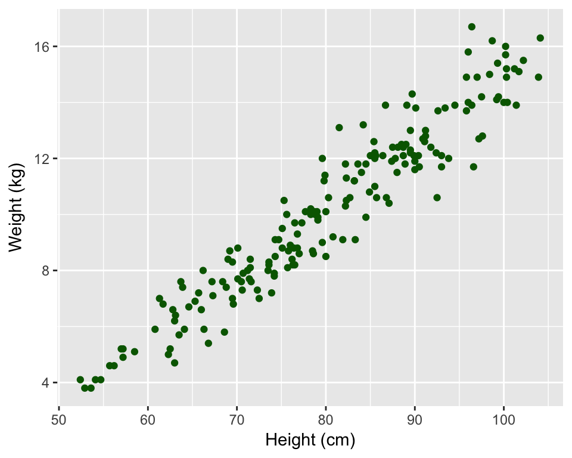

In this case, you'll define that aesthetic when you add the geom, outside of an `aes` statement.

In R, you can specify the shape of points with a number.

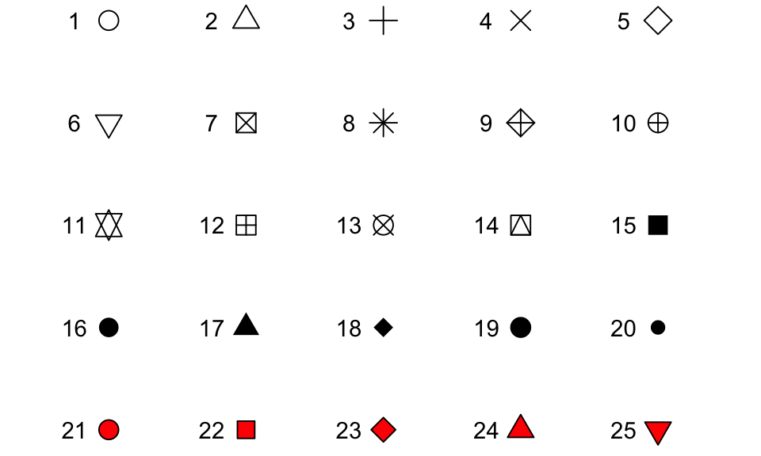

Examples of the shapes corresponding to different numeric choices for the `shape` aesthetic. For all examples, `color` is set to black and `fill` to red.

You can set a color in R using character strings for different colors.

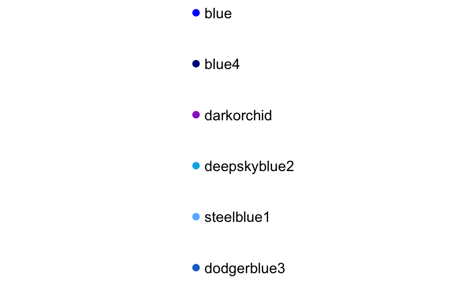

Example of available shades of blue in R.

### Useful plot additions

There are also a number of elements that you can add onto a `ggplot` object using `+`. A few that are used very frequently are:

| Element | Description |
| --- | --- |
| `ggtitle` | Plot title |
| `xlab`, `ylab` | x- and y-axis labels |
| `xlim`, `ylim` | Limits of x- and y-axis |

We’ll take a break now to continue with the in-course exercise Exploring data from an R package with basic plots, (Section @ref(in-course-exercise-eda).1).

### Example dataset

For the example plots, we use a dataset in the `faraway` package called `nepali`. This gives data from a study of the health of a group of Nepalese children.

```r
library(faraway)
data(nepali)
```

You need to load `dplyr` and `ggplot2`:

```r
library(dplyr)
library(ggplot2)
```

Each observation is a single measurement for a child; there can be multiple observations per child. We select only the columns for child id, sex, weight, height, and age and limit the dataset to only include one measurement for each child, the child's first measurement in the dataset (by the `distinct` function).

```r
nepali <- nepali %>%
  select(id, sex, wt, ht, age) %>%
  mutate(id = factor(id),
         sex = factor(sex, levels = c(1, 2),
                      labels = c("Male", "Female"))) %>%
  distinct(id, .keep_all = TRUE)
```

After this cleaning, the data looks like this:

```r
head(nepali)
```

```
#>       id    sex   wt    ht age
#> 1 120011   Male 12.8  91.2  41
#> 2 120012 Female 14.9 103.9  57
#> 3 120021 Female  7.7  70.1   8
#> 4 120022 Female 12.1  86.4  35
#> 5 120023   Male 14.2  99.4  49
#> 6 120031   Male 13.9  96.4  46
```

### Histograms

Histograms show the distribution of a single variable. Therefore, `geom_histogram()` requires only one main aesthetic, `x`. For example, to create a histogram of children's heights for the Nepali dataset (Figure @ref(fig:nepalihist1)), run:

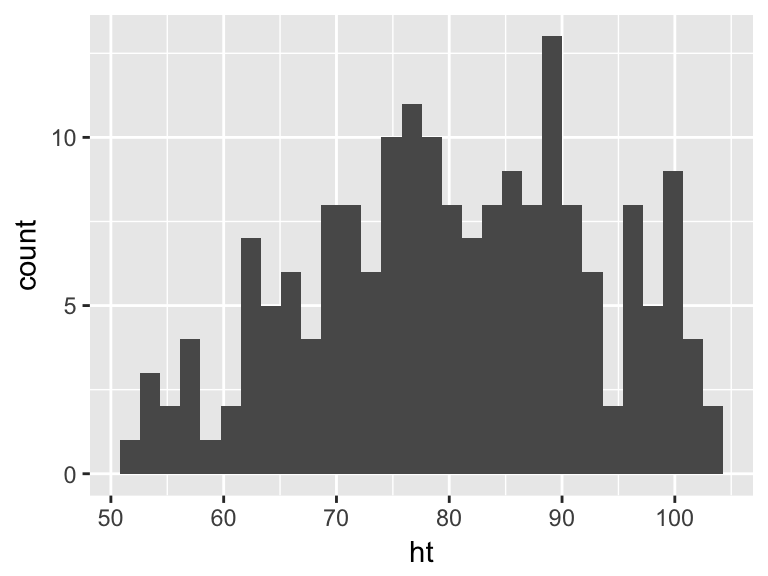

Histogram of height for the first recorded measurements of each child in the `nepali` dataset.

```r
ggplot(nepali, aes(x = ht)) +
  geom_histogram()
```

If you run the code with no arguments for `binwidth` or `bins`, you will get a message saying "`stat_bin()` using `bins = 30`. You may also get a message that observations with missing values were removed.

You can add some elements to the histogram. For example (Figure @ref(fig:nepalihist2)),

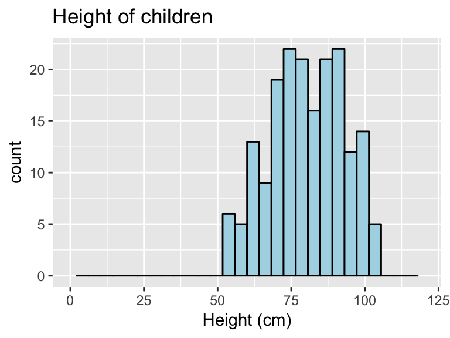

Example of adding ggplot elements to customize a histogram.

```r
ggplot(nepali, aes(x = ht)) +
  geom_histogram(fill = "lightblue", color = "black") +
  ggtitle("Height of children") +
  xlab("Height (cm)") + xlim(c(0, 120))
```

The geom `geom_histogram` also has special argument for setting the number of width of the bins used in the histogram. Figure @ref(fig:nepalihist3) shows an example of how you can use the `bins` argument .

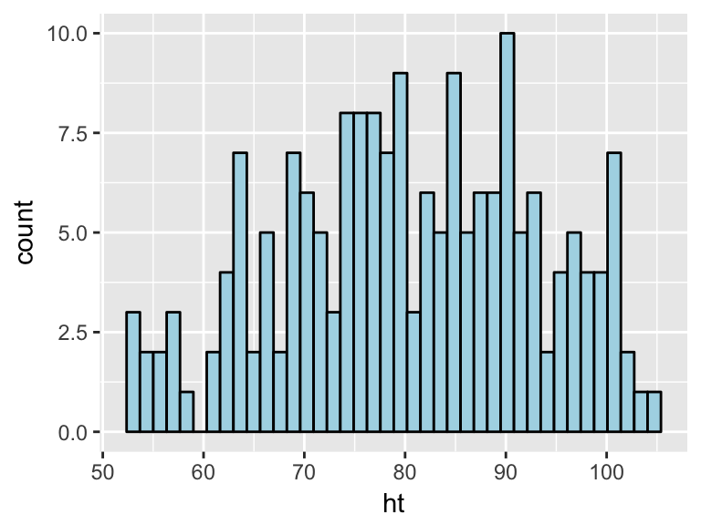

Example of using the `bins` argument to change the number of bins.

```r
ggplot(nepali, aes(x = ht)) +
  geom_histogram(fill = "lightblue", color = "black",
                 bins = 40)
```

Similarly, the `binwidth` argument can be used to set the width of bins. Figure @ref(fig:nepalihist4) shows an example with binwidths of 10 centimeters.

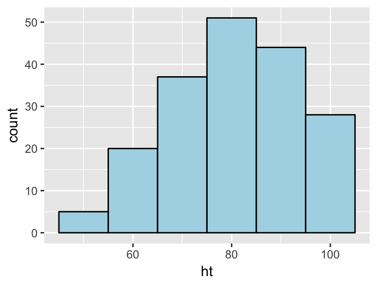

Example of using the `binwidth` argument to set the width of each bin.

```r
ggplot(nepali, aes(x = ht)) +
  geom_histogram(fill = "lightblue", color = "black",
                 binwidth = 10)
```

### Scatterplots

A scatterplot shows how one variable changes as another changes. You can use the `geom_point` geom. For example, to create a scatterplot of height versus weight for the Nepali data (Figure @ref(fig:nepaliscatter1)), you can run:

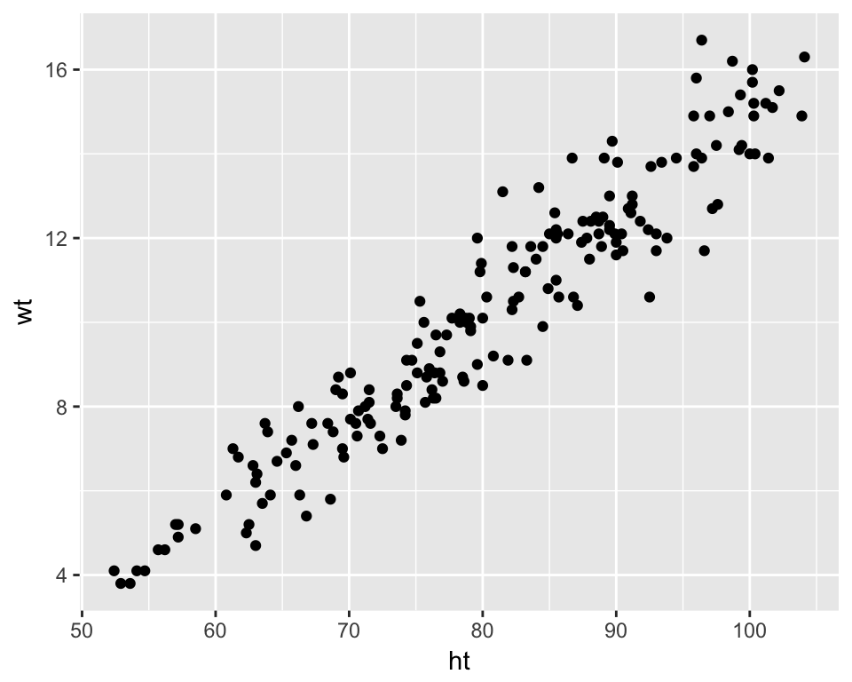

This scatterplot shows the relationship between children's heights and weights within the nepali dataset.

```r
ggplot(nepali, aes(x = ht, y = wt)) +
  geom_point()
```

Again, you can use some of the options and additions to change the plot appearance. For example, (Figure @ref(fig:nepaliscatter2)):

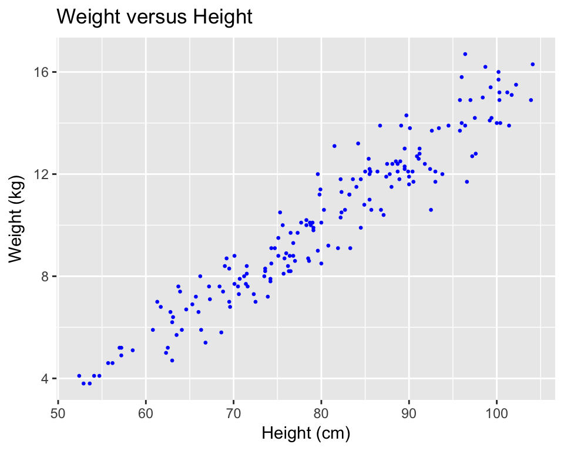

Example of adding ggplot elements to customize a scatterplot.

```r
ggplot(nepali, aes(x = ht, y = wt)) +
  geom_point(color = "blue", size = 0.5) +
  ggtitle("Weight versus Height") +
  xlab("Height (cm)") + ylab("Weight (kg)")
```

You can also try mapping another variable in the dataset to the `color` aesthetic. For example, to use color to show the sex of each child (Figure @ref(fig:nepaliscatter3)), you can run:

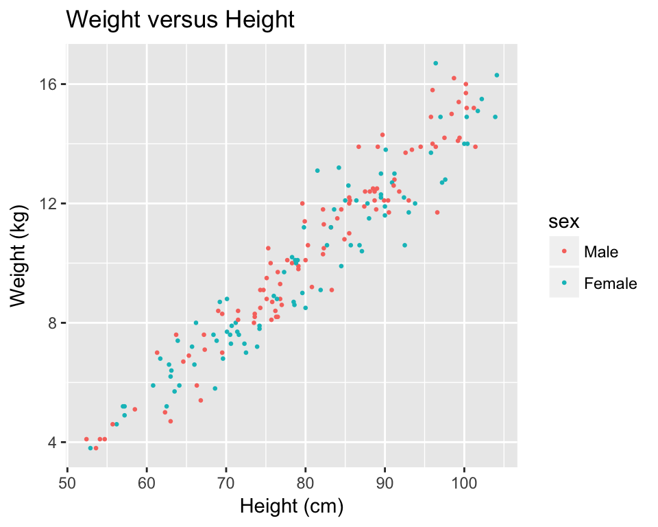

Example of mapping color to an element of the data in a scatterplot.

```r
ggplot(nepali, aes(x = ht, y = wt, color = sex)) +
  geom_point(size = 0.5) +
  ggtitle("Weight versus Height") +
  xlab("Height (cm)") + ylab("Weight (kg)")
```

#### Barcharts

You can use the geom_bar geom to create a barchart:

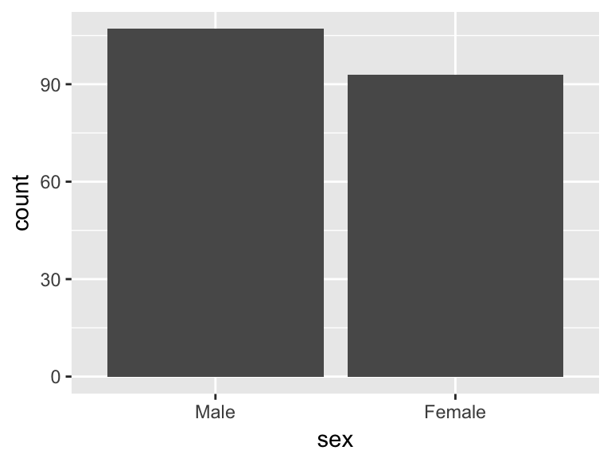

Barplot of sex for the first recorded measurements of each child in the `nepali` dataset.

```r
ggplot(nepali, aes(x = sex)) +
  geom_bar()
```

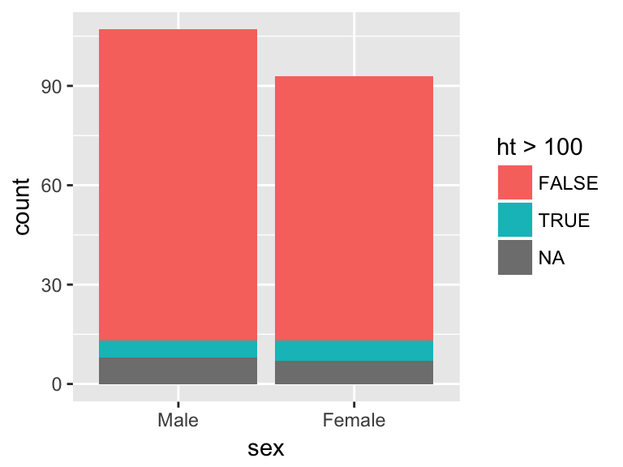

Barplot of sex for the first recorded measurements of each child in the `nepali` dataset.

```r
ggplot(nepali, aes(x = sex, fill = ht>100)) +
  geom_bar()
```

With the geom_bar geom, you can use the position argument to change how the bars for different groups are shown ("stack", "dodge", "fill"):

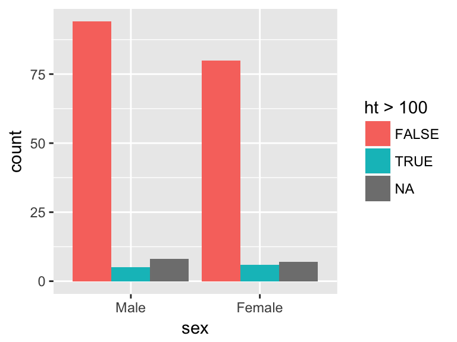

Barplot of sex for the first recorded measurements of each child in the `nepali` dataset.

```r
ggplot(nepali, aes(x = sex, fill = ht>100)) +
  geom_bar(position = "dodge")
```

### Boxplots

To create a boxplot, you can use the `geom_boxplot` geom. For example, to create a boxplot of the heights of children in the Nepali dataset (Figure @ref(fig:nepaliboxplot1)), you can run:

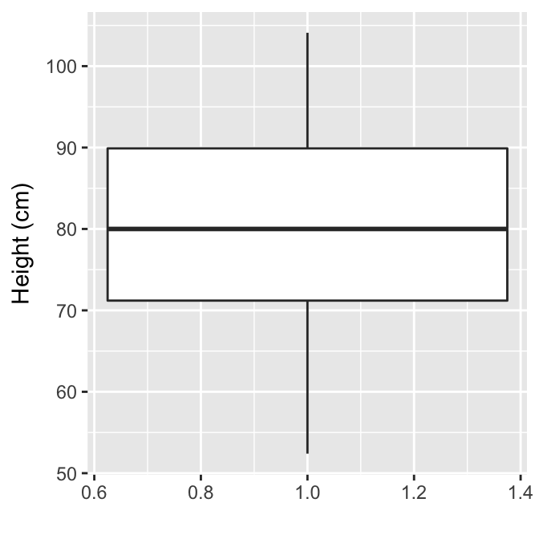

Boxplot of the distribution of height data for children in the nepali dataset.

```r
ggplot(nepali, aes(x = 1, y = ht)) +
  geom_boxplot() +
  xlab("")+ ylab("Height (cm)")
```

You can also create separate boxplots, one for each level of a factor (Figure @ref(fig:nepaliboxplot2)).

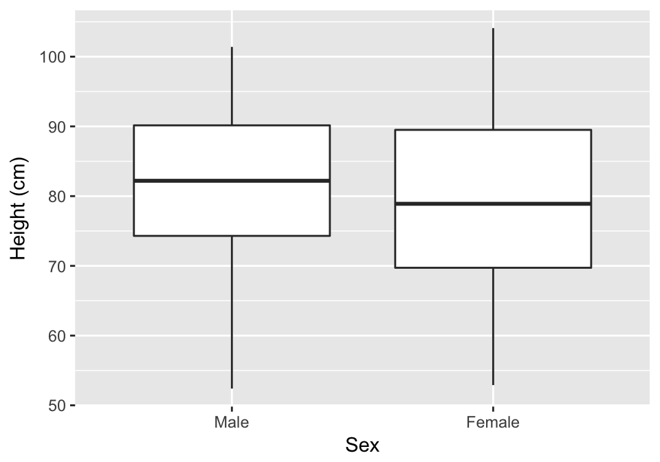

Example of creating separate boxplots, divided by a categorical grouping variable in the data.

```r
ggplot(nepali, aes(x = sex, y = ht, group = sex)) +
  geom_boxplot() +
  xlab("Sex")+ ylab("Height (cm)")
```

## Simple statistics functions

### Summary statistics

Here are some simple statistics functions:

| Function | Description |
| --- | --- |
| `range()` | Range (minimum and maximum) of vector |
| `min()`, `max()` | Minimum or maximum of vector |
| `mean()`, `median()` | Mean or median of vector |
| `sd()` | Standard deviation of vector |
| `table()` | Number of observations per level for a factor vector |
| `cor()` | Determine correlation(s) between two or more vectors |
| `summary()` | Summary statistics, depends on class |

All of these functions take, as the main argument, the vector or vectors for which you want the statistic. If there are missing values in the vector, you'll typically need to add an argument to say what to do with the missing values. The parameter name for many of these functions it's `na.rm = TRUE` or `use="complete.obs"`.

```r
mean(nepali$wt, na.rm = TRUE)
```

```
#> [1] 10.18432
```

```r
range(nepali$ht, na.rm = TRUE)
```

```
#> [1]  52.4 104.1
```

```r
sd(nepali$ht, na.rm = TRUE)
```

```
#> [1] 12.64529
```

```r
table(nepali$sex)
```

```
#>
#>   Male Female
#>    107     93
```

```r
cor(nepali$wt, nepali$ht, use = "complete.obs")
```

```
#> [1] 0.9571535
```

```r
cor((nepali %>% select(wt, ht, age)), use = "complete.obs")
```

```
#>            wt        ht       age
#> wt  1.0000000 0.9571535 0.8931195
#> ht  0.9571535 1.0000000 0.9287129
#> age 0.8931195 0.9287129 1.0000000
```

R supports object-oriented programming (OOP). Your first taste of this shows up with the `summary` function. For example,

```r
summary(nepali$wt)
```

```
#>    Min. 1st Qu.  Median    Mean 3rd Qu.    Max.    NA's
#>    3.80    7.90   10.10   10.18   12.40   16.70      15
```

```r
summary(nepali$sex)
```

```
#>   Male Female
#>    107     93
```

### `summarize` function

You will often want to use these functions in conjunction with the `summarize` function in `dplyr`. For example,

```r
nepali %>%
  summarize(mean_wt = mean(wt, na.rm = TRUE))
```

```
#>    mean_wt
#> 1 10.18432
```

There are also some special functions that you can use with `summarize`. For example, the `n` and the `first` functions:

```r
nepali %>%
  summarize(n_children = n(),
            first_id = first(id))
```

```
#>   n_children first_id
#> 1        200   120011
```

See the "summary function" section of the [the RStudio Data Wrangling cheatsheet](https://www.rstudio.com/wp-content/uploads/2015/02/data-wrangling-cheatsheet.pdf) for more examples of these special functions.

Often, you will be more interested in summaries within certain groupings. You just need to group data using the `group_by` function (from `dplyr`):

```r
nepali %>%
  group_by(sex) %>%
  summarize(mean_wt = mean(wt, na.rm = TRUE),
            n_children = n(),
            first_id = first(id))
```

```
#> # A tibble: 2 x 4
#>      sex   mean_wt n_children first_id
#>   <fctr>     <dbl>      <int>   <fctr>
#> 1   Male 10.497980        107   120011
#> 2 Female  9.823256         93   120012
```

What would be the coding by "not piping"?

We’ll take a break now to continue with the in-course exercise Exploring the data using simple statistics and `summarize`.

## In-course exercise EDA

### Exploring data from an R package with basic plots

Load the dataset called `worldcup` in the package `faraway`. Use the help file for the data to find out more about the dataset. Use some basic functions, like `head`, `tail`, `colnames`, `str`, and `summary` to check out the data a bit. See if you can figure out:

- What variables are included in this dataset?
- What class is each column currently?
1. Create a scatterplot of the `worldcup` data, where each point is a player, the x-axis shows the amount of time the player played in the World Cup, and the y-axis shows the number of passes the player had. Try writing the code both with and withing "piping in" the data you want to plot into the `ggplot` function.
2. Create the same scatterplot, but have each point in the scatterplot show that player's position. Add "rug plots" to the margins.
3. Create a scatterplot of number of shots (x-axis) versus number of tackles (y-axis) for **just** players on one of the four teams that made the semi-finals (Spain, Netherlands, Germany, Uruguay). Use color to show player's position and shape to show player's team. For an extra challenge, also try adding each player's name on top of each point.
4. Create a scatterplot of player time versus passes. Use color to show whether the player was on one of the top 4 teams or not.

### Exploring the data using simple statistics and `summarize`

1. What is the mean number of saves that players made?
2. What is the mean number of saves just among the goalkeepers?
3. Did players from any position other than goalkeeper make a save?
4. How many players were there in each position?
5. How many forwards were there on each team? Which team had the most shots in total among all its forwards?
6. Which team(s) had the defender with the most tackles?

If you have extra time, continuing using the "Data Wrangling" cheatsheet to come up with some other ideas for how you can explore this data, and write up and test code to do that.